# Driving Insights: Automotive Consumer Analysis with DuckDB and Dewey Data

Data Wrangling and Visualization — Course Assignment

Author

Michael Merrill | Tristan Farrow | Henrik Harman

Published

March 26, 2026

# Part 1: Assignment Prompt

## Background

You have just joined a small automotive market research consultancy as a junior data analyst. Your first client — a regional car dealership group — wants to understand *who* is buying *what* kind of vehicles, and whether demographic patterns (generation, income, gender) map onto brand preferences and fuel-type choices, including the ongoing shift toward electric vehicles.

Your manager hands you access to two linked datasets from **Dewey Data**:

- **Consumer Profiles** — one row per individual, rich demographic detail (generation, income tier, gender, state, homeownership, education, and much more)
- **Auto Ownership** — one row per individual, up to four registered vehicles per person, plus brand affinity scores for major manufacturers

Your job is to download the data, wire it up in DuckDB, wrangle it into an analysis-ready shape, and produce a polished multi-panel visualization your manager can put in front of the client.

## Setup Instructions

### Step 1 — Get Your Dewey Data Credentials

Before writing any code, you need two things from your Dewey Data account:

1. **Your API Key** — log in at deweydata.io, navigate to **Account → API Keys**, and copy your personal key.
2. **The Folder IDs** for the two datasets — in the Dewey Data file browser, open each dataset folder and copy the folder ID from the URL or folder details panel. You will need:
   - The **Consumer Profiles** folder ID
   - The **Auto Ownership** folder ID

> ⚠️ **Never hard-code your API key directly in your .qmd file.** Store it as an environment variable instead (see Task 1 below). This protects you when pushing to GitHub.

### Step 2 — Mac-Specific Setup

Open your **Terminal** (Applications → Utilities → Terminal) and add your API key to your shell environment file so it persists across sessions:

```bash
# For zsh (default on modern Macs — macOS Catalina and later)
echo 'export DEWEY_API_KEY="paste-your-key-here"' >> ~/.zshrc
source ~/.zshrc

# If you are on an older Mac using bash instead
echo 'export DEWEY_API_KEY="paste-your-key-here"' >> ~/.bash_profile
source ~/.bash_profile
```

Verify it worked:

```bash
echo $DEWEY_API_KEY
# Should print your key, not an empty line
```

You only need to do this **once**. After that, R can read it with `Sys.getenv("DEWEY_API_KEY")`.

### Step 2 - Windows specific

Windows stores environment variables differently than Mac. You have two options:

**Option A (Recommended) — Set a persistent User Environment Variable via System Settings:**

1. Press **Windows + R**, type `sysdm.cpl`, and hit Enter to open System Properties.
2. Go to the **Advanced** tab → click **Environment Variables**.
3. Under **User variables** (top section), click **New**.
4. Set **Variable name** to `DEWEY_API_KEY` and **Variable value** to your actual key.
5. Click OK → OK → OK to save.
6. **Restart RStudio** (or any open R sessions) so it picks up the new variable.

Verify it worked by running this in the R console:

```r
Sys.getenv("DEWEY_API_KEY")
# Should print your key, not an empty string ""
```

**Option B — Use a `.Renviron` file (no system settings needed):**

1. In RStudio, open the R console and run:

   ```r
   usethis::edit_r_environ()
   ```

   This opens (or creates) a `.Renviron` file in your home directory.
2. Add this line to the file:

   ```
   DEWEY_API_KEY=paste-your-key-here
   ```

3. Save the file and restart R (**Session → Restart R** in RStudio).

> ⚠️ **Add `.Renviron` to your `.gitignore`** — never push it to GitHub.

**Finding your file paths on Windows:**

Unlike Mac where paths look like `/Users/yourname/...`, Windows paths look like `C:/Users/yourname/...`. In R, always use **forward slashes** (`/`) even on Windows — backslashes (`\`) cause problems in R strings.

To find your current working directory path in R:

```r
getwd()
# Example output: "C:/Users/yourname/Documents/my-project"
```

**If `deweyr` fails because `uvx` is not found on Windows:**

The `deweyr` package uses `uvx` internally. If you get an error about `uvx` not being found, run this in your R console to add the typical install location to R’s PATH for the session:

```r
# Common install location when uv is installed via the official installer
Sys.setenv(PATH = paste(
  "C:/Users/yourname/AppData/Local/uv/bin",
  Sys.getenv("PATH"),
  sep = ";"   # Windows uses semicolons to separate PATH entries
))
```

Replace `yourname` with your actual Windows username. You can find your username by opening **Command Prompt** and typing `echo %USERNAME%`.

To make this fix permanent, add `uv`’s bin folder to your **User Environment Variables** PATH entry using the same System Properties dialog from Option A above.

## Tasks

### Task 1 — Download the Data via `deweyr`

Install and load the `deweyr` package, then use it to download **both** datasets from Dewey Data to a local folder. Store your API key and folder IDs as environment variables or in a local `.Renviron` file — **do not paste them directly into your code**.

Your code should:

1. Install `deweyr` from GitHub (include this in a chunk with `eval: false` so it does not re-run on every render)
2. Read your API key from the environment using `Sys.getenv()`
3. Download the Consumer Profiles dataset to `data/consumer-profiles/`
4. Download the Auto Ownership dataset to `data/auto-ownership/`
5. Confirm the downloads succeeded by listing the files in each folder

**Hint:** The `dewey_download()` function accepts `api_key`, `folder_id`, and `download_path` arguments. See the README for the full parameter list including date-partition filtering.

### Task 2 — Connect DuckDB and Register the Parquet Files

Once the files are downloaded, connect to an in-memory DuckDB database and register the parquet files as virtual tables — without loading them fully into R memory.

Your code should:

1. Load `duckdb` and `DBI` and open an in-memory connection
2. Use a SQL `CREATE VIEW` statement to register the Consumer Profiles parquet file(s) as a view called `profiles`
3. Do the same for the Auto Ownership parquet file(s) as a view called `auto`
4. Run a quick `SELECT * FROM profiles LIMIT 5` and `SELECT * FROM auto LIMIT 5` to confirm both views are accessible
5. Use `duckplyr` to pull each view into R as a tibble for downstream wrangling

**Hint:** If there are multiple parquet files in a folder (Dewey Data sometimes partitions large datasets), DuckDB can read them all at once with a glob pattern: `read_parquet('data/auto-ownership/*.parquet')`

**File path note (Mac):** The path inside `read_parquet()` is relative to your `.qmd` file’s location. If you saved downloads to your Mac’s Downloads folder you can use the full path: `read_parquet('/Users/your-mac-username/Downloads/dewey-downloads/auto-ownership/*.parquet')` You can also find your exact path in Terminal by running `pwd` inside the data folder.

### Task 3 — Decode and Wrangle the Data

Both datasets use coded values for categorical variables. Before you can analyze anything meaningfully, you need to decode the most important ones. You will also need to reshape the Auto Ownership dataset, which stores up to four vehicles per person in wide format (`make1`, `make2`, `make3`, `make4`, etc.).

**3a. Decode the following columns in the Consumer Profiles dataset:**

| Column | Code → Label |
| --- | --- |
| `generation_grpcd` | B = Baby Boomer, X = Gen X, M = Millennial, S = Silent Generation |
| `gender` | M = Male, F = Female |
| `ehi_v2` (estimated household income) | A = Under $20K, B = $20–$29K, C = $30–$39K, D = $40–$49K, E = $50–$59K, F = $60–$74K, G = $75–$99K, H = $100–$124K, I = $125–$149K, J = $150–$174K, K = $175–$199K, L = $200–$249K, M = $250K+ |
| `homeownercd` | H = Homeowner, R = Renter, U = Unknown |
| `educationcd` | A = Less than HS, B = HS Graduate, C = Some College, F = College Graduate |

**3b. Decode the following columns in the Auto Ownership dataset:**

| Column | Code → Label |
| --- | --- |
| `fueltypecd1` | G = Gasoline, F = Flex Fuel, B = Battery Electric (EV), D = Diesel, H = Hybrid |

**3c. Pivot the Auto Ownership dataset from wide to long format** so that each row represents one vehicle (not one person). After pivoting, a person with three registered vehicles should appear as three rows. Your long-format table should have at minimum: `pid`, `vehicle_slot` (1–4), `make`, `model`, `year`, `fuel_type`, `veh_class`, `style`.

**3d. Join** the decoded long-format vehicle table to the decoded consumer profiles table on `pid`, keeping only rows where both datasets have a match.

### Task 4 — Query with DuckDB SQL

Write the following queries using **raw SQL** via `DBI::dbGetQuery()` against your DuckDB connection. Do not use dplyr for these — the point is to practice SQL directly.

**Query A:** How many vehicles of each `veh_class` are in the dataset? Order by count descending.

**Query B:** What is the average `in_market_new_score` by `generation_grpcd`? Only include rows where the score is not NULL. Round to 2 decimal places.

**Query C:** Among vehicles where `fueltypecd1` is Battery Electric (EV), what are the top 5 most common makes? Return make and count.

**Query D:** Write a query that shows the breakdown of fuel type (`fueltypecd1`) by generation. Your result should have one row per generation/fuel-type combination, with a column for count and a column for the percentage of that generation’s vehicles that fuel type represents. Round percentage to 1 decimal place.

### Task 5 — duckplyr Wrangling

Now use `duckplyr` — which lets you write familiar `dplyr`-style code that executes via DuckDB under the hood — to answer the following. Reference the [duckplyr basics guide](https://pdsr.rtemis.org/duckplyrBasics) as needed.

**5a.** Using `filter()` and `summarize()` with `.by`, find the mean `suv_affinity` and `truck_affinity` score by generation. Arrange the result by generation.

**5b.** Using `mutate()`, create a new column called `is_ev` that is `TRUE` when `fueltypecd1 == "B"` (Battery Electric) and `FALSE` otherwise. Then use `count()` grouped by `generation` and `is_ev` to summarize EV adoption by generation.

**5c.** Using `slice_max()`, find the single individual (by `pid`) with the highest `in_market_new_score` in each generation group. What vehicles do they own?

### Task 6 — Multi-Panel Visualization

Using `ggplot2`, create a **single multi-panel figure** (using `patchwork` or `facet_wrap`) that tells a coherent story about automotive consumer behavior from this dataset. Your figure must include **at least three panels** and address at least two of the following angles:

- Vehicle class or style preferences by generation
- EV / fuel type adoption patterns (overall or by demographic group)
- Brand affinity scores across demographic segments
- Income tier and vehicle class or brand relationships

Requirements:

- Each panel must have a clear, informative title
- Axes must be labeled (no raw column name defaults)
- Use a consistent, clean theme across all panels
- Include a figure caption (use Quarto’s `#| fig-cap:` chunk option) summarizing the overall story in 1–2 sentences
- Color palettes must be accessible (consider `scale_fill_viridis_d()` or `ggthemes`)

### Task 7 — Written Summary

Write **two paragraphs** directly in your .qmd (not as a code comment) summarizing:

1. What you found — the key patterns in the data and what they suggest about the dealership client’s target segments
2. What you would want to explore next with a larger pull of this data, and what limitations the sample size imposes on your current conclusions

### Submission

Render your `.qmd` file to HTML. Push the following files to your GitHub repository:

- `your-name-dewey-automotive.qmd`
- `your-name-dewey-automotive.html`
- `your-name-dewey-automotive.md` (if generated)

> ⚠️ **Do NOT push your `data/` folder or any parquet files to GitHub.** Add `data/` to your `.gitignore` file. Your API key must never appear in any pushed file.

Submit a link to the `.html` file on GitHub via I-Learn.

# Part 2: Solution Walkthrough

> This section presents a fully worked solution to the assignment above. It is intended for classroom review and as a reference example for practitioners exploring Dewey Data with R, DuckDB, and duckplyr. Code is annotated throughout to explain the reasoning behind each step.

## 0 — Package Setup

```r
#This code might be good, but I am running into some errors right now
#knitr::opts_chunk$set(echo = TRUE, message = FALSE, warning = FALSE, error = TRUE)

# Install deweyr from GitHub (run once — eval: false in production)
# install.packages("devtools")
# devtools::install_github("Coxabc/deweyr")

library(deweyr)       # Dewey Data download wrapper
library(duckdb)       # DuckDB database engine
library(DBI)          # Database interface (standard R DB layer)
library(duckplyr)     # dplyr-syntax interface to DuckDB
library(tidyverse)    # dplyr, tidyr, ggplot2, stringr, etc.
library(patchwork)    # Multi-panel ggplot2 composition
```

## 1 — Downloading the Data

### 1a. API Key and Folder IDs

Your API key lives in your environment, never in your code. On a Mac, you added it to `~/.zshrc` during setup (see Part 1 instructions). R reads it at runtime like this:

```r
# ── WHERE TO PUT YOUR CREDENTIALS ──────────────────────────────────────────
#
#  OPTION A (recommended): Environment variable set in ~/.zshrc (Mac)
#    Already done during setup. Just use Sys.getenv() below.
#
#  OPTION B: .Renviron file in your project root
#    Create a file called .Renviron (no extension) in your project folder.
#    Add these two lines to it — then restart R:
#
#      DEWEY_API_KEY=paste-your-api-key-here
#
#    R loads .Renviron automatically on startup.
#    ADD .Renviron TO YOUR .gitignore — never push it to GitHub.
#
# ───────────────────────────────────────────────────────────────────────────

api_key <- Sys.getenv("DEWEY_API_KEY")

# ── FOLDER IDs ──────────────────────────────────────────────────────────────
#  Find these in the Dewey Data file browser:
#  1. Log in at deweydata.io
#  2. Navigate to the dataset folder
#  3. Copy the folder ID from the URL or the folder details panel
#
#  Replace the placeholders below with your actual folder IDs:

folder_id_profiles <- "https://api.deweydata.io/api/v1/external/data/prj_ry8qacnd__cdst_gkqw4ccfiduozhia" # Consumer profile folder, this one happens to be filtered to Utah, Idaho and California
folder_id_auto     <- "https://api.deweydata.io/api/v1/external/data/prj_ry8qacnd__cdst_6vgodnvf8johkhbk" # Auto ownership folder, this one happens to be filtered down too a few common domestic and foreign brands
```

Run this in the console if it says that uvx is not found, this was specifically for my Mac:

Sys.setenv(PATH = paste(“/Users/mckennahudson/.local/bin”, Sys.getenv(“PATH”), sep = “:”))

## 2 — Connect DuckDB and Register Parquet Files

After `dewey_download()` runs, your parquet files will be sitting in the two local folders you created. DuckDB can read them directly off disk — no need to load them into R memory first. This is one of DuckDB’s biggest advantages: you can query files that are far larger than your available RAM.

```r
# Open an in-memory DuckDB connection
# (DuckDB handles the file I/O itself — "in-memory" just means no separate DB file)
con <- dbConnect(duckdb())

# ── Register parquet files as DuckDB views ──────────────────────────────────
#
# The glob pattern *.parquet picks up ALL parquet files in a folder at once.
# Dewey Data sometimes splits large datasets across multiple partitioned files —
# the glob handles that automatically.
#
# IMPORTANT: these paths are relative to your .qmd file's location.
# If your .qmd is at ~/Documents/my-project/analysis.qmd, then
# "data/consumer-profiles/*.parquet" resolves to
# ~/Documents/my-project/data/consumer-profiles/*.parquet
#
# Adjust the paths below if you saved your files to a different location.
# For example, if you used an absolute path like /Users/yourname/Downloads/dewey-downloads/
# just paste that full path in place of "data/consumer-profiles".

# Register auto ownership
dbExecute(con, "
  CREATE VIEW auto AS
  SELECT * FROM read_parquet('/Users/mckennahudson/DS488_DS_Consulting/data/auto-ownership/auto-ownership-domestic-foreign-brands/*.snappy.parquet')
")

# Register consumer profiles
dbExecute(con, "
  CREATE VIEW profiles AS
  SELECT * FROM read_parquet('/Users/mckennahudson/DS488_DS_Consulting/data/consumer-profiles/idaho-utah-california-consumer-profile/*.snappy.parquet')
")

# Confirm both work
dbGetQuery(con, "SELECT * FROM auto LIMIT 3")
dbGetQuery(con, "SELECT * FROM profiles LIMIT 3")
```

[output not shown]

Ok, now I will check that the data is good

```r
# See exact column names as they appear in the real data (uppercase)
dbGetQuery(con, "SELECT column_name FROM information_schema.columns
                 WHERE table_name = 'auto' LIMIT 20")

dbGetQuery(con, "SELECT column_name FROM information_schema.columns
                 WHERE table_name = 'profiles'
                 AND column_name IN ('PID','GENDER','GENERATION_GRPCD',
                                     'EHI_V2','STATE','AGE','HOMEOWNERCD',
                                     'EDUCATIONCD','WEALTHSCR_V2')")
```

[output not shown]

Then join and filter within duck db before trying to pull into R

```r
# Do the heavy join inside DuckDB — only pull key columns into R
# This avoids loading 300+ columns x 12M rows into memory
vehicles <- dbGetQuery(con, "
  SELECT
    a.PID,
    a.MAKE1, a.MAKE2, a.MAKE3, a.MAKE4,
    a.MODEL1, a.MODEL2, a.MODEL3, a.MODEL4,
    a.YEAR1, a.YEAR2, a.YEAR3, a.YEAR4,
    a.FUELTYPECD1, a.FUELTYPECD2, a.FUELTYPECD3, a.FUELTYPECD4,
    a.VEH_CLASS1, a.VEH_CLASS2, a.VEH_CLASS3, a.VEH_CLASS4,
    a.STYLECD1, a.STYLECD2, a.STYLECD3, a.STYLECD4,
    a.SUV_AFFINITY, a.TRUCK_AFFINITY, a.SEDAN_AFFINITY,
    a.HYBRID_AFFINITY, a.TOYOTA_AFFINITY, a.FORD_AFFINITY,
    a.HONDA_AFFINITY, a.CHEVROLET_AFFINITY,
    a.IN_MARKET_NEW_SCORE, a.IN_MARKET_USED_SCORE,
    p.GENDER, p.GENERATION_GRPCD, p.EHI_V2,
    p.STATE, p.AGE, p.HOMEOWNERCD, p.EDUCATIONCD,
    p.WEALTHSCR_V2, p.MARRIEDCD
  FROM auto a
  INNER JOIN profiles p ON a.PID = p.PID
") |> as_tibble()

# How many matched?
nrow(vehicles)
n_distinct(vehicles$PID)
```

[output not shown]

## 3 — Decode and Wrangle the Data

### 3a–3b. Decode Categorical Codes

The datasets use compact letter codes for categorical variables. We decode the most important ones up front so that all downstream analysis and visualizations use human-readable labels.

```r
generation_labels <- c(
  "S" = "Silent Generation",
  "B" = "Baby Boomer",
  "X" = "Gen X",
  "M" = "Millennial"
)

income_labels <- c(
  "A" = "Under $20K", "B" = "$20-29K", "C" = "$30-39K",
  "D" = "$40-49K",   "E" = "$50-59K", "F" = "$60-74K",
  "G" = "$75-99K",   "H" = "$100-124K","I" = "$125-149K",
  "J" = "$150-174K", "K" = "$175-199K","L" = "$200-249K",
  "M" = "$250K+"
)

fuel_labels <- c(
  "G" = "Gasoline", "F" = "Flex Fuel",
  "B" = "Battery Electric", "D" = "Diesel", "H" = "Hybrid"
)

vehicles_clean <- vehicles |>
  mutate(
    generation  = generation_labels[GENERATION_GRPCD],
    generation  = factor(generation, levels = generation_labels),
    gender      = case_when(GENDER == "M" ~ "Male",
                            GENDER == "F" ~ "Female",
                            TRUE ~ NA_character_),
    income_tier = income_labels[EHI_V2],
    income_tier = factor(income_tier, levels = income_labels, ordered = TRUE),
    fuel_type1  = fuel_labels[FUELTYPECD1],
    is_ev       = FUELTYPECD1 == "B",
    across(c(SUV_AFFINITY, TRUCK_AFFINITY, SEDAN_AFFINITY,
             HYBRID_AFFINITY, IN_MARKET_NEW_SCORE), as.numeric)
  )

glimpse(vehicles_clean)
```

[output not shown]

Pivot to long format so that now there will only be one vehicle per row:

```r
vehicles_long <- vehicles_clean |>
  pivot_longer(
    cols = matches("^(MAKE|MODEL|YEAR|FUELTYPECD|VEH_CLASS|STYLECD)[1-4]$"),
    names_to  = c(".value", "slot"),
    names_pattern = "^([A-Z_]+?)([1-4])$"
  ) |>
  rename(
    make       = MAKE,
    model      = MODEL,
    year       = YEAR,
    fuel_code  = FUELTYPECD,
    veh_class  = VEH_CLASS,
    style      = STYLECD
  ) |>
  mutate(
    fuel_type = fuel_labels[fuel_code],
    is_ev     = fuel_code == "B",
    year      = as.integer(year)
  ) |>
  filter(!is.na(make))

cat("Total vehicles (long):", nrow(vehicles_long), "\n")
cat("Unique owners:        ", n_distinct(vehicles_long$PID), "\n")
count(vehicles_long, slot)
```

[output not shown]

So now we are building the plots

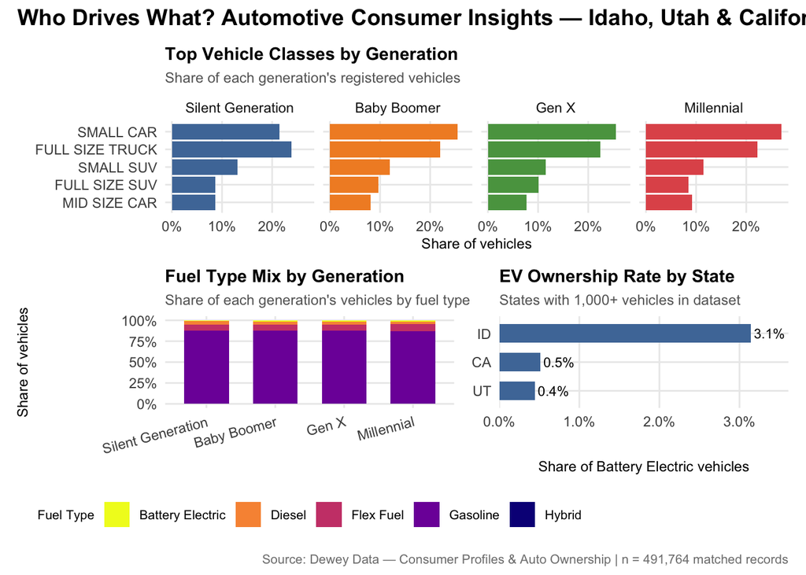

```r
library(patchwork)

# ── Shared theme ────────────────────────────────────────────────────────────
theme_dewey <- theme_minimal(base_size = 11) +
  theme(
    plot.title       = element_text(face = "bold", size = 11),
    plot.subtitle    = element_text(size = 9, color = "gray40"),
    axis.title       = element_text(size = 9),
    legend.position  = "bottom",
    legend.title     = element_text(size = 8),
    legend.text      = element_text(size = 8),
    panel.grid.minor = element_blank()
  )

gen_colors <- c(
  "Silent Generation" = "#4e79a7",
  "Baby Boomer"       = "#f28e2b",
  "Gen X"             = "#59a14f",
  "Millennial"        = "#e15759"
)

# ── Panel 1 — Top vehicle classes by generation ─────────────────────────────
p1_data <- vehicles_long |>
  filter(!is.na(generation), !is.na(veh_class)) |>
  count(generation, veh_class) |>
  group_by(generation) |>
  mutate(pct = n / sum(n)) |>
  ungroup() |>
  group_by(generation) |>
  slice_max(pct, n = 5) |>
  ungroup()

p1 <- ggplot(p1_data,
             aes(x = reorder(veh_class, pct),
                 y = pct,
                 fill = generation)) +
  geom_col(show.legend = FALSE) +
  scale_y_continuous(labels = scales::percent_format(accuracy = 1)) +
  scale_fill_manual(values = gen_colors) +
  coord_flip() +
  facet_wrap(~ generation, nrow = 1) +
  labs(
    title    = "Top Vehicle Classes by Generation",
    subtitle = "Share of each generation's registered vehicles",
    x        = NULL,
    y        = "Share of vehicles"
  ) +
  theme_dewey

# ── Panel 2 — Fuel type by generation ───────────────────────────────────────
p2_data <- vehicles_long |>
  filter(!is.na(generation), !is.na(fuel_type)) |>
  count(generation, fuel_type) |>
  group_by(generation) |>
  mutate(pct = n / sum(n)) |>
  ungroup()

p2 <- ggplot(p2_data,
             aes(x = generation, y = pct, fill = fuel_type)) +
  geom_col(position = "fill", width = 0.65) +
  scale_y_continuous(labels = scales::percent_format()) +
  scale_fill_viridis_d(option = "plasma", name = "Fuel Type", direction = -1) +
  labs(
    title    = "Fuel Type Mix by Generation",
    subtitle = "Share of each generation's vehicles by fuel type",
    x        = NULL,
    y        = "Share of vehicles"
  ) +
  theme_dewey +
  theme(axis.text.x = element_text(angle = 15, hjust = 1))

# ── Panel 3 — EV ownership by state (top 10 states) ─────────────────────────
p3_data <- vehicles_long |>
  filter(!is.na(STATE), !is.na(fuel_type)) |>
  group_by(STATE) |>
  summarize(
    pct_ev = mean(fuel_code == "B", na.rm = TRUE),
    n      = n(),
    .groups = "drop"
  ) |>
  filter(n > 1000) |>
  slice_max(pct_ev, n = 10)

p3 <- ggplot(p3_data,
             aes(x = reorder(STATE, pct_ev), y = pct_ev)) +
  geom_col(fill = "#4e79a7", width = 0.65) +
  geom_text(aes(label = scales::percent(pct_ev, accuracy = 0.1)),
            hjust = -0.1, size = 3) +
  scale_y_continuous(labels = scales::percent_format(accuracy = 0.1),
                     expand = expansion(mult = c(0, 0.15))) +
  coord_flip() +
  labs(
    title    = "EV Ownership Rate by State",
    subtitle = "States with 1,000+ vehicles in dataset",
    x        = NULL,
    y        = "Share of Battery Electric vehicles"
  ) +
  theme_dewey

# ── Combine ──────────────────────────────────────────────────────────────────
combined <- (p1 / (p2 | p3)) +
  plot_annotation(
    title   = "Who Drives What? Automotive Consumer Insights — Idaho, Utah & California",
    caption = "Source: Dewey Data — Consumer Profiles & Auto Ownership | n = 491,764 matched records",
    theme   = theme(
      plot.title   = element_text(size = 14, face = "bold"),
      plot.caption = element_text(size = 8, color = "gray50")
    )
  )

combined
```

I THOUGHT I WAS DONE HERE AT LINE 709

## 4 — Query with DuckDB SQL

We register the wrangled data back into DuckDB and write raw SQL queries. This mirrors what you would do in a production pipeline querying large parquet files.

```r
# Write the wrangled + joined tibble back into DuckDB as a table for SQL querying.
# (It came FROM DuckDB via parquet → we wrangled it in R → now we push it back
#  so we can practice raw SQL against it in Tasks 4 and 5.)
dbWriteTable(con, "vehicles", vehicles, overwrite = TRUE)
```

**Query A — Vehicle class counts:**

```r
dbGetQuery(con, "
  SELECT VEH_CLASS1 AS vehicle_class,
         COUNT(*) AS n_vehicles
  FROM   auto
  WHERE  VEH_CLASS1 IS NOT NULL
  GROUP  BY VEH_CLASS1
  ORDER  BY n_vehicles DESC
")
```

```
     vehicle_class n_vehicles
1  FULL SIZE TRUCK    2600703
2        SMALL CAR    2592674
3        SMALL SUV    2152764
4     MID SIZE CAR    1027791
5    FULL SIZE SUV     922482
6    FULL SIZE CAR     908813
7        CROSSOVER     706665
8          MINIVAN     504138
9   MID SIZE TRUCK     260716
10     SMALL TRUCK     223631
11   FULL SIZE VAN      77046
12    MID SIZE SUV       9499
```

**Query B — Average in-market new score by generation:**

```r
dbGetQuery(con, "
  SELECT p.GENERATION_GRPCD AS generation,
         ROUND(AVG(a.IN_MARKET_NEW_SCORE), 2) AS avg_new_score,
         COUNT(*) AS n
  FROM   auto a
  JOIN   profiles p ON a.PID = p.PID
  WHERE  a.IN_MARKET_NEW_SCORE IS NOT NULL
    AND  p.GENERATION_GRPCD IS NOT NULL
  GROUP  BY p.GENERATION_GRPCD
  ORDER  BY avg_new_score DESC
")
```

```
  generation avg_new_score      n
1          B         57.94 160565
2          X         50.93 161186
3          S         46.33   8867
4          M         26.60    436
```

**Query C — Top 5 EV makes:**

```r
dbGetQuery(con, "
  SELECT MAKE1 AS make,
         COUNT(*) AS n_ev_vehicles
  FROM   auto
  WHERE  FUELTYPECD1 = 'B'
  GROUP  BY MAKE1
  ORDER  BY n_ev_vehicles DESC
  LIMIT  5
")
```

```
       make n_ev_vehicles
1      FORD        124095
2 CHEVROLET         25956
```

**Query D — Fuel type breakdown by generation:**

```r
dbGetQuery(con, "
  WITH gen_totals AS (
    SELECT p.GENERATION_GRPCD AS generation,
           COUNT(*) AS total_in_gen
    FROM   auto a
    JOIN   profiles p ON a.PID = p.PID
    WHERE  p.GENERATION_GRPCD IS NOT NULL
    GROUP  BY p.GENERATION_GRPCD
  ),
  fuel_counts AS (
    SELECT p.GENERATION_GRPCD AS generation,
           a.FUELTYPECD1      AS fuel_type_code,
           COUNT(*) AS n
    FROM   auto a
    JOIN   profiles p ON a.PID = p.PID
    WHERE  p.GENERATION_GRPCD IS NOT NULL
      AND  a.FUELTYPECD1      IS NOT NULL
    GROUP  BY p.GENERATION_GRPCD, a.FUELTYPECD1
  )
  SELECT fc.generation,
         fc.fuel_type_code,
         fc.n,
         ROUND(100.0 * fc.n / gt.total_in_gen, 1) AS pct_of_generation
  FROM   fuel_counts fc
  JOIN   gen_totals  gt USING (generation)
  ORDER  BY fc.generation, fc.n DESC
")
```

```
   generation fuel_type_code      n pct_of_generation
1           B              G 140951              76.4
2           B              F  16758               9.1
3           B              Y  11500               6.2
4           B              D   5534               3.0
5           B              B   2765               1.5
6           B              I   1544               0.8
7           B              L    539               0.3
8           B              N    198               0.1
9           B              H     20               0.0
10          B              P     15               0.0
11          M              G    494              78.7
12          M              F     54               8.6
13          M              Y     29               4.6
14          M              D     12               1.9
```

[output cut: 21 more lines]

## 5 — duckplyr Wrangling

`duckplyr` lets us write familiar dplyr-style pipelines that execute inside DuckDB, combining the readability of the tidyverse with the performance of columnar query execution.

```r
# Convert our joined tibble to a duckplyr data frame
vehicles_dk <- vehicles |> as_duckdb_tibble()
```

**5a — Brand affinity by generation:**

```r
generation_labels <- c("S"="Silent Generation","B"="Baby Boomer",
                        "X"="Gen X","M"="Millennial")

vehicles_dk <- vehicles |> as_duckdb_tibble()

affinity_by_gen <- vehicles_dk |>
  filter(!is.na(GENERATION_GRPCD)) |>
  mutate(generation = generation_labels[GENERATION_GRPCD]) |>
  summarize(
    mean_suv_affinity   = mean(SUV_AFFINITY,  na.rm = TRUE),
    mean_truck_affinity = mean(TRUCK_AFFINITY, na.rm = TRUE),
    n = n(),
    .by = generation
  ) |>
  arrange(generation)

affinity_by_gen
```

```
# A duckplyr data frame: 4 variables
  generation        mean_suv_affinity mean_truck_affinity      n
  <chr>                         <dbl>               <dbl>  <int>
1 Baby Boomer                    2.20                2.40 184461
2 Gen X                          2.26                2.48 184008
3 Millennial                     1.88                2.41    628
4 Silent Generation              2.21                2.59  10280
```

**5b — EV adoption by generation:**

```r
vehicles_long <- vehicles_long |>
  mutate(
    generation  = as.character(unname(generation)),
    income_tier = as.character(unname(income_tier)),
    fuel_type   = as.character(unname(fuel_type)),
    fuel_type1  = as.character(unname(fuel_type1))
  )

vehicles_long_dk <- vehicles_long |>
  select(-GENDER, -GENERATION_GRPCD, -EHI_V2) |>  # drop raw cols that have decoded equivalents
  as_duckdb_tibble()


ev_by_gen <- vehicles_long_dk |>
  filter(!is.na(generation)) |>
  mutate(is_ev = fuel_code == "B") |>
  count(generation, is_ev) |>
  mutate(label = if_else(is_ev, "Battery Electric", "Non-EV")) |>
  arrange(generation, is_ev)

ev_by_gen
```

```
# A duckplyr data frame: 4 variables
   generation        is_ev      n label
   <chr>             <lgl>  <int> <chr>
 1 Baby Boomer       FALSE 619129 Non-EV
 2 Baby Boomer       TRUE    7298 Battery Electric
 3 Baby Boomer       NA     12509 <NA>
 4 Gen X             FALSE 627704 Non-EV
 5 Gen X             TRUE    8319 Battery Electric
 6 Gen X             NA     11408 <NA>
 7 Millennial        FALSE   2012 Non-EV
 8 Millennial        TRUE      28 Battery Electric
 9 Millennial        NA        48 <NA>
10 Silent Generation FALSE  34605 Non-EV
11 Silent Generation TRUE     289 Battery Electric
12 Silent Generation NA       561 <NA>
```

**5c — Highest in-market score per generation:**

```r
top_buyers <- vehicles_long_dk |>
  filter(!is.na(generation), !is.na(IN_MARKET_NEW_SCORE)) |>
  slice_max(IN_MARKET_NEW_SCORE, by = generation, n = 1, with_ties = FALSE) |>
  select(generation, PID, IN_MARKET_NEW_SCORE, make, model, year,
         fuel_type, veh_class, income_tier) |>
  arrange(generation)

top_buyers
```

```
# A duckplyr data frame: 9 variables
  generation     PID   IN_MARKET_NEW_SCORE make  model  year fuel_type veh_class
  <chr>          <chr>               <dbl> <chr> <chr> <int> <chr>     <chr>
1 Baby Boomer    5743…                 100 HONDA PILOT  2006 Gasoline  SMALL SUV
2 Gen X          52A9…                 100 CHEV… CAMA…  2013 Gasoline  MID SIZE…
3 Millennial     63A9…                  92 FORD  FUSI…  2011 Gasoline  MID SIZE…
4 Silent Genera… 4E90…                 100 CHEV… IMPA…  2013 Flex Fuel FULL SIZ…
# ℹ 1 more variable: income_tier <chr>
```

## 6 — Multi-Panel Visualization

We build a three-panel figure that tells a unified story: *How do generation and income shape the kinds of vehicles Americans own, and where does the EV transition stand?*

```r
# ── Shared theme ────────────────────────────────────────────────────────────
theme_dewey <- theme_minimal(base_size = 11) +
  theme(
    plot.title       = element_text(face = "bold", size = 11),
    plot.subtitle    = element_text(size = 9, color = "gray40"),
    axis.title       = element_text(size = 9),
    legend.position  = "bottom",
    legend.title     = element_text(size = 8),
    legend.text      = element_text(size = 8),
    panel.grid.minor = element_blank(),
    strip.text       = element_text(face = "bold", size = 9)
  )

# Generation color palette (colorblind-friendly)
gen_colors <- c(
  "Silent Generation" = "#4e79a7",
  "Baby Boomer"       = "#f28e2b",
  "Gen X"             = "#59a14f",
  "Millennial"        = "#e15759"
)
```

```r
p1_data <- vehicles_long |>
  filter(!is.na(generation), !is.na(veh_class)) |>
  count(generation, veh_class) |>
  group_by(generation) |>
  mutate(pct = n / sum(n)) |>
  ungroup()

p1 <- ggplot(p1_data,
             aes(x = reorder(veh_class, pct, FUN = mean),  # mean across generations for stable order
                 y = pct,
                 fill = generation)) +
  geom_col(position = "dodge", width = 0.7) +
  scale_y_continuous(labels = scales::percent_format(accuracy = 1)) +
  scale_fill_manual(values = gen_colors, name = "Generation") +
  coord_flip() +
  labs(
    title    = "Vehicle Class Preferences by Generation",
    subtitle = "Proportion of each generation's registered vehicles",
    x        = NULL,
    y        = "Share of vehicles"
  ) +
  theme_dewey
```

```r
# Panel 2 — Fuel type by generation (stacked 100%)
p2_data <- vehicles_long |>
  filter(!is.na(generation), !is.na(fuel_type)) |>
  count(generation, fuel_type) |>
  group_by(generation) |>
  mutate(pct = n / sum(n)) |>
  ungroup()

p2 <- ggplot(p2_data,
             aes(x = generation, y = pct, fill = fuel_type)) +
  geom_col(position = "fill", width = 0.65) +
  scale_y_continuous(labels = scales::percent_format()) +
  scale_fill_viridis_d(option = "plasma", name = "Fuel Type", direction = -1) +
  labs(
    title    = "Fuel Type Mix by Generation",
    subtitle = "100% stacked — share of each generation's vehicles by fuel type",
    x        = NULL,
    y        = "Share of vehicles"
  ) +
  theme_dewey +
  theme(axis.text.x = element_text(angle = 15, hjust = 1))
```

```r
# Panel 3 — SUV vs Truck affinity scores by income tier
# Use only the person-level data (one row per pid) to avoid double-counting
income_order <- c("Under $20K","$20-29K","$30-39K","$40-49K","$50-59K",
                  "$60-74K","$75-99K","$100-124K","$125-149K",
                  "$150-174K","$175-199K","$200-249K","$250K+")

p3_data <- vehicles_long |>
  distinct(PID, .keep_all = TRUE) |>        # one row per person to avoid double-counting
  filter(!is.na(income_tier)) |>
  mutate(income_tier = factor(income_tier, levels = income_order)) |>
  group_by(income_tier) |>
  summarize(
    mean_suv   = mean(SUV_AFFINITY,   na.rm = TRUE),
    mean_truck = mean(TRUCK_AFFINITY, na.rm = TRUE),
    .groups = "drop"
  ) |>
  pivot_longer(cols = c(mean_suv, mean_truck),
               names_to  = "affinity_type",
               values_to = "mean_score") |>
  mutate(
    affinity_type = recode(affinity_type,
                           "mean_suv"   = "SUV Affinity",
                           "mean_truck" = "Truck Affinity")
  )

p3 <- ggplot(p3_data,
             aes(x = income_tier, y = mean_score,
                 color = affinity_type, group = affinity_type)) +
  geom_line(linewidth = 1) +
  geom_point(size = 2.5) +
  scale_color_manual(values = c("SUV Affinity"   = "#4e79a7",
                                "Truck Affinity" = "#e15759"),
                     name = NULL) +
  scale_x_discrete(guide = guide_axis(angle = 45)) +
  labs(
    title    = "SUV vs. Truck Affinity Across Income Tiers",
    subtitle = "Mean affinity score (1 = low, 4 = high) by estimated household income",
    x        = "Income Tier",
    y        = "Mean Affinity Score"
  ) +
  theme_dewey
```

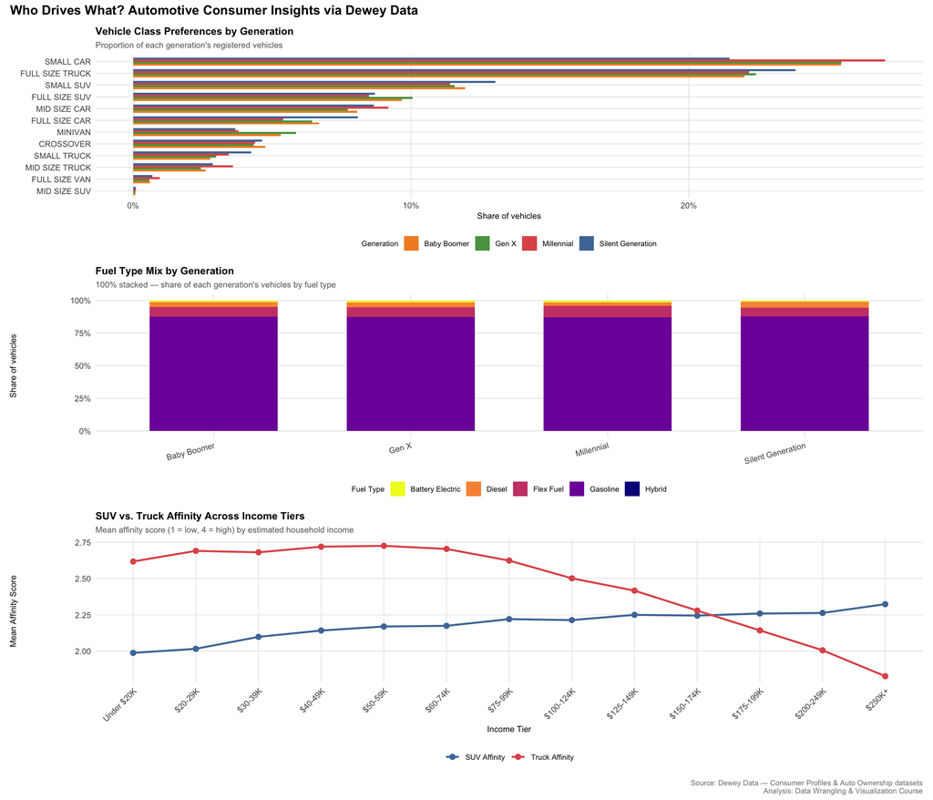

```r
# Compose the three panels with patchwork
combined <- (p1 / p2 / p3) +
  plot_annotation(
    title   = "Who Drives What? Automotive Consumer Insights via Dewey Data",
    caption = "Source: Dewey Data — Consumer Profiles & Auto Ownership datasets\nAnalysis: Data Wrangling & Visualization Course",
    theme   = theme(
      plot.title   = element_text(size = 14, face = "bold"),
      plot.caption = element_text(size = 8, color = "gray50")
    )
  )

combined
```

# References

## References

InfutorData. (2024). *Consumer Profiles* [Dataset]. Dewey Data. https://doi.org/10.82551/GVTF-Q257

InfutorData. (2024). *Auto Ownership* [Dataset]. Dewey Data. https://doi.org/10.82551/5358-6S46